# Optimizing COVID-19 Vaccination Strategies

#### *A Comprehensive Data Analysis Approach To Identify The Optimal Vaccine*

### Problem Statement:

The different facets of the existing COVID-19 vaccinations, such as their efficacy, cost, side effects, and availability, do not, however, have thorough and comparable data analysis. This project will utilizing a statistical study of COVID-19 vaccinations for the top 10 afflicted countries, and will offer insights on which vaccine is the best option for each nation based on a variety of variables.

### 1. *Vaccination Implemented by Top 10 Countries:*

The provided data represents the cumulative count of individuals impacted by the COVID-19 virus in the ten most heavily affected countries as of June 2023. Additionally, it outlines the various vaccination strategies implemented by these countries to combat the spread of the virus:

```r
  library(dplyr)
  # Create the dataframe with labeled columns
  df <- data.frame(
    Country = c("Usa", "India", "France", "Germany", "Brazil", "Japan", "South Korea", "Italy", "UK", "Russia"),
    `CoVID Affected Patient` = c("106,792,474", "44,980,674", "40,044,973", "38,417,622", "37,511,921", "33,803,572", "31,415,280", "25,828,252", "24,569,895", "22,898,376"),
    Vaccines = c("Pfizer, Moderna, J&J", "Covishield, Covaxin, Sputnik V", "AstraZeneca, Pfizer, Moderna, J&J", "AstraZeneca, Pfizer, Moderna, J&J", "Coronavac, Covishield, Pfizer, J&J", "Pfizer, Moderna, J&J, AstraZeneca", "Covishield, Pfizer, J&J, Moderna", "Pfizer, Modena, J&J, AstraZeneca", "Pfizer, Moderna, J&J, AstraZeneca", "Sputnik V, EpiVacCorona,CoviVac"),
    check.names = FALSE
  )

  # Display the dataframe
  df
```

```
##        Country CoVID Affected Patient                           Vaccines
## 1          Usa            106,792,474               Pfizer, Moderna, J&J
## 2        India             44,980,674     Covishield, Covaxin, Sputnik V
## 3       France             40,044,973  AstraZeneca, Pfizer, Moderna, J&J
## 4      Germany             38,417,622  AstraZeneca, Pfizer, Moderna, J&J
## 5       Brazil             37,511,921 Coronavac, Covishield, Pfizer, J&J
## 6        Japan             33,803,572  Pfizer, Moderna, J&J, AstraZeneca
## 7  South Korea             31,415,280   Covishield, Pfizer, J&J, Moderna
## 8        Italy             25,828,252   Pfizer, Modena, J&J, AstraZeneca
## 9           UK             24,569,895  Pfizer, Moderna, J&J, AstraZeneca
## 10      Russia             22,898,376    Sputnik V, EpiVacCorona,CoviVac
```

### 2. *Exploring and Analyzing the Data through Multiple Dimensions*

1. Here’s an example of the countries and the vaccines implemented by them:

```r
# Display only the "Vaccines" and "Country" columns
df_selected <- select(df, Vaccines, Country)

# Display the selected columns
df_selected
```

```
##                              Vaccines     Country
## 1                Pfizer, Moderna, J&J         Usa
## 2      Covishield, Covaxin, Sputnik V       India
## 3   AstraZeneca, Pfizer, Moderna, J&J      France
## 4   AstraZeneca, Pfizer, Moderna, J&J     Germany
## 5  Coronavac, Covishield, Pfizer, J&J      Brazil
## 6   Pfizer, Moderna, J&J, AstraZeneca       Japan
## 7    Covishield, Pfizer, J&J, Moderna South Korea
## 8    Pfizer, Modena, J&J, AstraZeneca       Italy
## 9   Pfizer, Moderna, J&J, AstraZeneca          UK
## 10    Sputnik V, EpiVacCorona,CoviVac      Russia
```

2. Here’s an example of the countries and the following count of CoVID-19 affected patients:

```r
# Display the "Country" and "CoVID Affected Patient" columns
df_selected <- select(df, Country, `CoVID Affected Patient`)

# Display the selected columns
df_selected
```

```
##        Country CoVID Affected Patient
## 1          Usa            106,792,474
## 2        India             44,980,674
## 3       France             40,044,973
## 4      Germany             38,417,622
## 5       Brazil             37,511,921
## 6        Japan             33,803,572
## 7  South Korea             31,415,280
## 8        Italy             25,828,252
## 9           UK             24,569,895
## 10      Russia             22,898,376
```

3. Here’s an example of the top 3 countries affected by CoVID-19:

```r
# Sort the data based on the number of COVID-19 affected patients in descending order
df_sorted <- df[order(-as.numeric(gsub(",", "", df$`CoVID Affected Patient`))), ]

# Display the top 3 countries with the most affected COVID-19 patients
df_top_3 <- head(df_sorted, 3)

# Display the top 3 countries
df_top_3
```

```
##   Country CoVID Affected Patient                          Vaccines
## 1     Usa            106,792,474              Pfizer, Moderna, J&J
## 2   India             44,980,674    Covishield, Covaxin, Sputnik V
## 3  France             40,044,973 AstraZeneca, Pfizer, Moderna, J&J
```

4. Here’s an example of the countries with the lowest COVID-19 impact among the top 10 severely affected nations:

```r
# Sort the data based on the number of COVID-19 affected patients in ascending order
df_sorted <- df[order(as.numeric(gsub(",", "", df$`CoVID Affected Patient`))), ]

# Display the top 3 countries with the least affected COVID-19 patients
df_top_3 <- head(df_sorted, 3)

# Display the top 3 countries
df_top_3
```

```
##    Country CoVID Affected Patient                          Vaccines
## 10  Russia             22,898,376   Sputnik V, EpiVacCorona,CoviVac
## 9       UK             24,569,895 Pfizer, Moderna, J&J, AstraZeneca
## 8    Italy             25,828,252  Pfizer, Modena, J&J, AstraZeneca
```

```r
# Filter the dataframe for countries that used the Pfizer vaccine
df_pfizer_countries <- filter(df, grepl("Pfizer", Vaccines, ignore.case = TRUE))

# Display the countries that used the Pfizer vaccine
df_pfizer_countries$Country
```

```
## [1] "Usa"         "France"      "Germany"     "Brazil"      "Japan"
## [6] "South Korea" "Italy"       "UK"
```

```r
# Filter the dataframe for countries that used the Covishield vaccine
df_covishield_countries <- filter(df, grepl("Covishield", Vaccines, ignore.case = TRUE))

# Display the countries that used the Covishield vaccine
df_covishield_countries$Country
```

```
## [1] "India"       "Brazil"      "South Korea"
```

7. Here’s a graphical display of the affected population from our data:

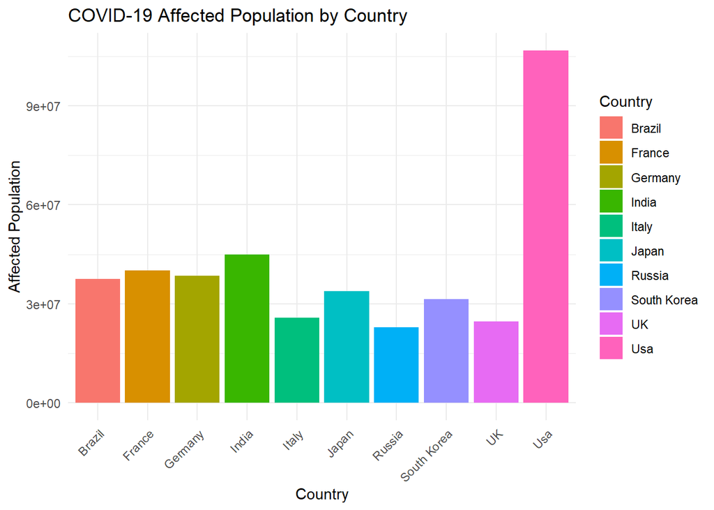

```r
library(ggplot2)
# Convert the affected population to numeric
df$`CoVID Affected Patient` <- as.numeric(gsub(",", "", df$`CoVID Affected Patient`))

# Create a bar plot using ggplot
ggplot(df, aes(x = Country, y = `CoVID Affected Patient`, fill = Country)) +
  geom_bar(stat = "identity") +
  labs(x = "Country", y = "Affected Population",
       title = "COVID-19 Affected Population by Country") +
  theme_minimal() +
  theme(axis.text.x = element_text(angle = 45, hjust = 1))
```

#### 3. *Pie Chart to display the countries*

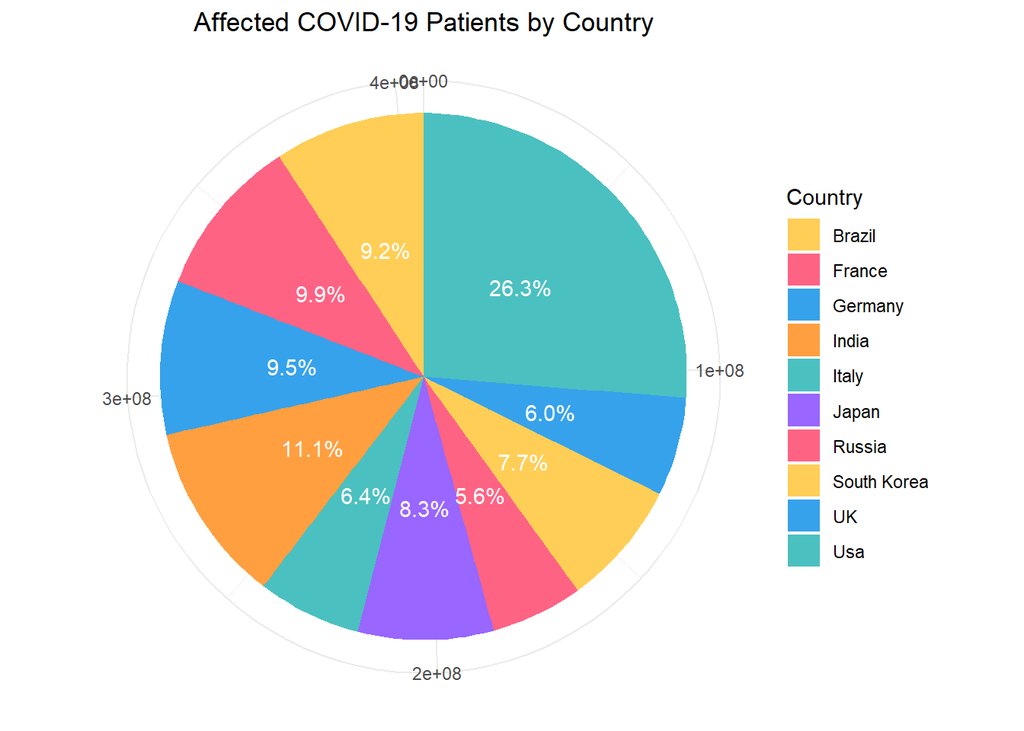

```r
# Define custom colors for each country
custom_colors <- c("#FFCE56", "#FF6384", "#36A2EB", "#FF9F40", "#4BC0C0", "#9966FF", "#FF6384", "#FFCE56", "#36A2EB", "#4BC0C0")
# Calculate the total affected patients
total_affected <- sum(df$`CoVID Affected Patient`)

# Create a pie chart with percentage labels
pie_chart <- ggplot(df, aes(x = "", y = `CoVID Affected Patient`, fill = factor(Country))) +
  geom_bar(stat = "identity", width = 1) +
  coord_polar("y", start = 0) +
  labs(fill = "Country", x = NULL, y = NULL, title = "Affected COVID-19 Patients by Country") +
  geom_text(aes(label = paste0(sprintf("%.1f%%", (`CoVID Affected Patient` / total_affected) * 100))), position = position_stack(vjust = 0.5), color = "white") +
  theme_minimal() +
  theme(legend.position = "right", plot.title = element_text(hjust = 0.5)) +
  scale_fill_manual(values = custom_colors)

# Display the pie chart
print(pie_chart)
```